# 2_Enhanced_Visualization

### Using Alternative Statistics

Using t-score instead of p-value for the y-axis can be particularly useful in single-cell analysis. Due to the large number of cells in single-cell datasets, p-values often become extremely significant, causing many genes to cluster at the top of the y-axis when using -log10(p-value). This can make it difficult to distinguish between genes that are all technically highly significant. T-scores provide better spread and can help create more informative visualizations.

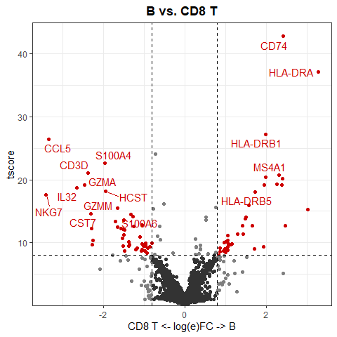

```r
VolcanoPlot(
  pbmc,
  ident.1 = "B",
  ident.2 = "CD8 T",
  y = "tscore"
)
```

> the tscore is the test statistic from the differential expression test (essentially the “t-value”) rather than a p-value.

SeuratExtend allows you to use the tscore instead of p-values on the y-axis:

- tscore = test statistic (from the Wilcoxon test or t-test, depending on method used).
- It directly reflects the strength of difference between groups, without converting to p-values.
- Larger absolute tscore = stronger separation between groups.

> Why use tscore?
- Better spread on the y-axis → makes it easier to see relative differences between genes.
- Avoids the “ceiling effect” of –log10(p) when all p-values are near zero.
- Especially helpful in big scRNA-seq datasets (like PBMCs with thousands of cells).

### Using Log2 or Log10 Fold Change (New in v1.2.0)

By default, VolcanoPlot uses natural logarithm (base e) for fold change calculations. You can specify a different base using the `log.base` parameter:

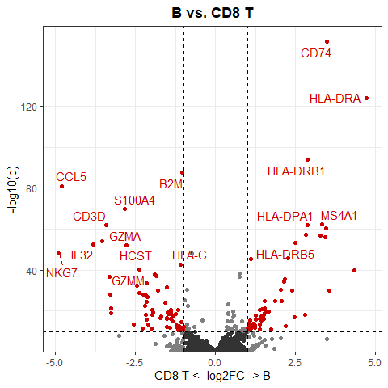

```r
VolcanoPlot(
  pbmc,
  ident.1 = "B",
  ident.2 = "CD8 T",
  log.base = "2"    # Use log2 instead of natural log
)
```

### Matrix Input

You can also use matrices, such as pathway enrichment scores:

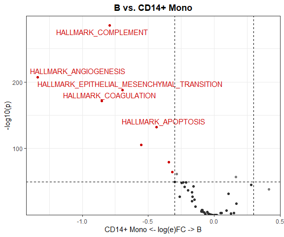

```r
# Using the previously calculated pathway enrichment scores
VolcanoPlot(
  matr,
  f = pbmc$cluster,
  ident.1 = "B",
  ident.2 = "CD14+ Mono",
  x.quantile = 0.8,
  y.quantile = 0.8,
  top.n = 5)
```

## Tips: Choosing the Right Visualization

When visualizing gene expression or pathway activity data, different plot types serve different purposes. Here’s a guide to help you choose:

1. Overview Visualizations:
   - **Heatmaps**:
     - Best for: Comparing many features across multiple groups using color intensity
     - Advantage: Compact visualization of large-scale patterns
     - Limitation: Color intensity alone may not show detailed expression patterns
   - **Dot Plots**:
     - Best for: Similar to heatmaps but with additional information
     - Advantage: Shows both expression level (color) and percent expressing cells (size)
     - Limitation: Takes more space than heatmaps
2. Two-Group Comparisons:
   - **Waterfall Plots**:
     - Best for: Ordered visualization of differences between two groups
     - Advantage: Clear ranking of most differential features
     - Limitation: Limited to two-group comparisons
   - **Volcano Plots**:
     - Best for: Combining fold change with statistical significance
     - Advantage: Shows both effect size and significance
     - Limitation: Also limited to two-group comparisons
3. Detailed Expression Analysis:
   - **Violin Plots**:
     - Best for: Detailed view of expression distribution
     - Advantage: Shows full distribution shape and statistical comparisons
     - Limitation: Space-intensive, limiting the number of features that can be shown

## Explore Color Functions

The `SeuratExtend` package provides comprehensive color management across all visualization functions. Each function type handles colors slightly differently depending on whether it’s dealing with discrete or continuous variables.

### For Functions Handling Discrete Variables

- **DimPlot2**, **VlnPlot2**, **ClusterDistrBar** (using `cols` parameter)
  - Eight color_pro styles: “default”, “light”, “pro_red”, “pro_yellow”, “pro_green”, “pro_blue”, “pro_purple”, “bright” (new in v1.2.0)
  - Five color_iwh styles: “iwh_default”, “iwh_intense”, “iwh_pastel”, “iwh_all”, “iwh_all_hard”
  - All RColorBrewer qualitative palettes (e.g., “Set1”, “Set2”, “Set3”, “Paired”, “Dark2”, “Accent”, “Pastel1”, “Pastel2”)
  - Custom colors as vector of hex codes or color names

> **Note**: Based on user feedback, starting from v1.2.0, the default discrete color scheme has been changed to “light” to avoid color inconsistency in DimPlot2 when toggling between labeled and unlabeled displays. If you prefer to retain the original “default” (darker) color scheme for discrete variables in `DimPlot2`, you can use: `seu <- save_colors(seu, col_list = list("discrete" = "default"))`. This will set the default for all discrete variables to the darker color scheme.

### For Functions Handling Continuous Variables

- **DimPlot2** (using `cols` parameter for continuous features)
- **Heatmap**, **DotPlot2**, **WaterfallPlot** (using `color_scheme` parameter)

Available options for continuous variables:

1. Viridis Color Schemes (see viridis palettes
   - Options “A” through “H” from the viridis package
   - Example: `cols = "D"` for the ‘viridis’ option
2. (New in v1.1.0) RColorBrewer Sequential Palettes
   - Options include: “Blues”, “BuGn”, “BuPu”, “GnBu”, “Greens”, “Greys”, “Oranges”, “OrRd”, “PuBu”, “PuBuGn”, “PuRd”, “Purples”, “RdPu”, “Reds”, “YlGn”, “YlGnBu”, “YlOrBr”, “YlOrRd”
   - Add “-rev” suffix to reverse any palette (e.g., “Blues-rev”)
3. (New in v1.1.0) RColorBrewer Diverging Palettes
   - Options include: “BrBG”, “PiYG”, “PRGn”, “PuOr”, “RdBu”, “RdGy”, “RdYlBu”, “RdYlGn”, “Spectral”
   - Add “-rev” suffix to reverse any palette
4. (New in v1.1.0) Custom Diverging Palettes
   - Additional options: “GnYlRd”, “BuYlRd”, “GyRd”, “BuRd”, “PuOr”
5. Custom Gradient Specifications
   - Three-point gradient: `c(low = "blue", mid = "white", high = "red")`
   - Two-point gradient: `c(low = "grey", high = "red")`
   - Vector of colors for custom gradient

### Recommended Color Schemes

Here are some recommended color schemes for different visualization needs in single-cell analysis:

#### For Discrete Variables (e.g., clusters, conditions)

The “default” (dark) theme and “light” color scheme from SeuratExtend’s `color_pro` are particularly effective for different visualization needs:

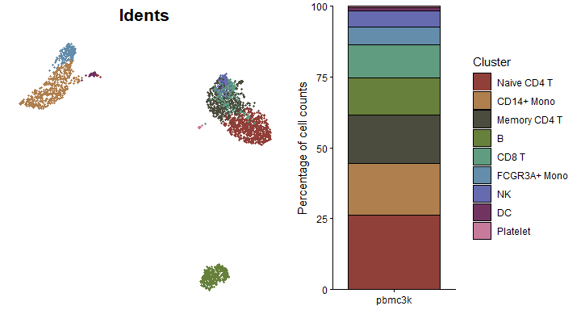

```r
library(cowplot)
plot_grid(
  DimPlot2(pbmc, cols = "default", theme = NoAxes() + NoLegend()),
  ClusterDistrBar(pbmc$orig.ident, pbmc$cluster, cols = "default", flip = FALSE, border = "black") +
    theme(axis.title.x = element_blank())
)
```

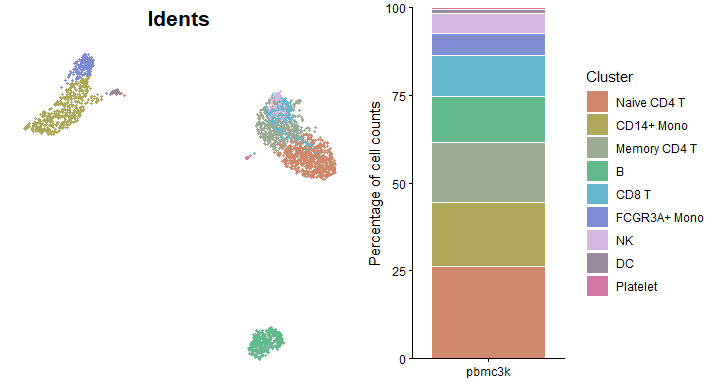

```r
library(cowplot)
plot_grid(
  DimPlot2(pbmc, cols = "light", theme = NoAxes() + NoLegend()),
  ClusterDistrBar(pbmc$orig.ident, pbmc$cluster, cols = "light", flip = FALSE) +
    theme(axis.title.x = element_blank())
)
```

For visualizations requiring more vibrant colors with high contrast (new in v1.2.0):

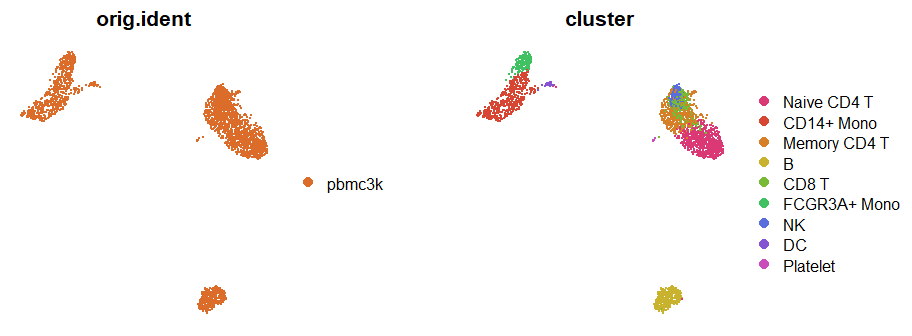

```r
plot_grid(
  DimPlot2(pbmc, features = c("orig.ident", "cluster"), cols = "bright", ncol = 2, theme = NoAxes())
)
```

#### For Continuous Variables (e.g., gene expression)

the “A” or “D” color schemes from viridis:

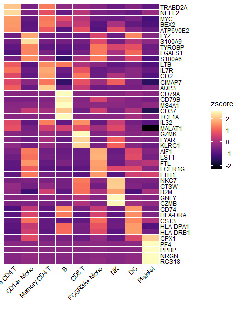

```r
Heatmap(toplot, lab_fill = "zscore", color_scheme = "A")
```

```
## Using pseudocount = 1 for logFC calculation.
```

```
## Ignoring unknown labels:
## • colour : "-log10(p)"
```

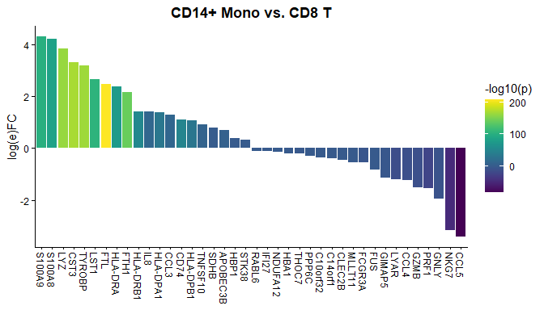

```r
WaterfallPlot(
  pbmc, group.by = "cluster", features = VariableFeatures(pbmc)[1:80],
  ident.1 = "CD14+ Mono", ident.2 = "CD8 T", length = "logFC",
  top.n = 20, color_theme = "D")
```

You can also use various color palettes from RColorBrewer (https://r-graph-gallery.com/38-rcolorbrewers-palettes.html):

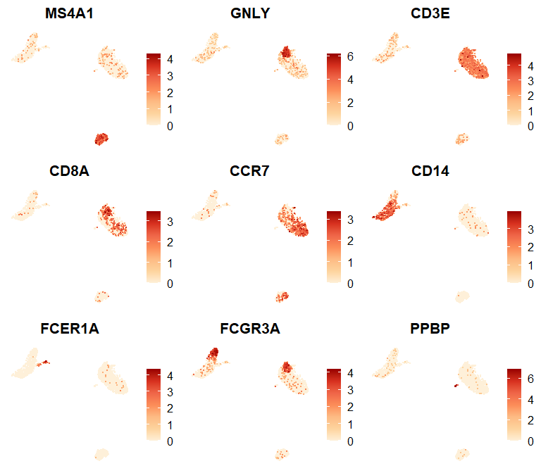

```r
library(RColorBrewer)
markers_genes <- c(
  "MS4A1", "GNLY", "CD3E",
  "CD8A", "CCR7", "CD14",
  "FCER1A", "FCGR3A", "PPBP")
DimPlot2(
  pbmc,
  features = markers_genes,
  cols = "OrRd",
  theme = NoAxes())
```

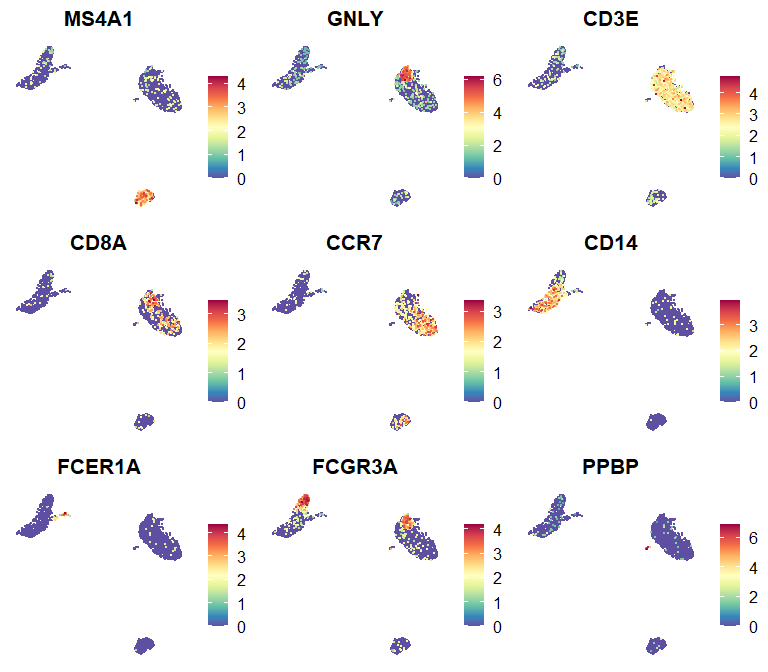

```r
DimPlot2(
  pbmc,
  features = markers_genes,
  cols = "Spectral-rev",
  theme = NoAxes())
```

### Professional Discrete Color Presets with `color_pro`

The `color_pro` function is designed to generate professional discrete color presets, ideal for data science visualizations, particularly in fields like scRNA-seq analysis where aesthetics must not compromise the clarity and seriousness of scientific communication.

#### The Philosophy Behind `color_pro`

Choosing the right colors for scientific visualizations is crucial. Colors must be distinct enough to differentiate data points clearly but coordinated and subdued enough to maintain professionalism and avoid visual strain.

##### What to AVOID in Scientific Plotting

1. **Coordinated but Indistinct Colors:** Using monochromatic schemes can reduce visual distinction, which might cause data points to blend together.

   Example of an inadvisable choice:

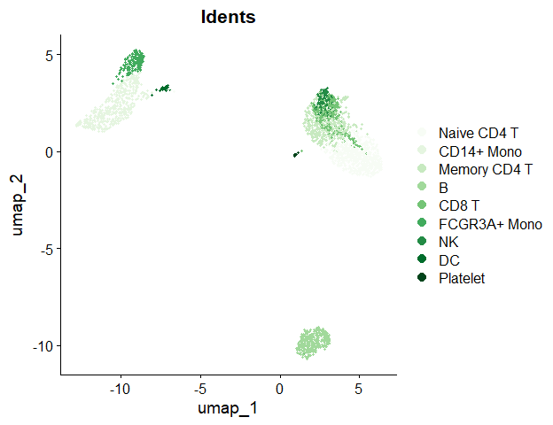

```r
   DimPlot2(pbmc, cols = "Greens")
```

2. **Sufficiently Distinct but Overly Saturated Colors:** High saturation can be visually aggressive and distracting, detracting from the scientific message.

   Example of overly saturated colors:

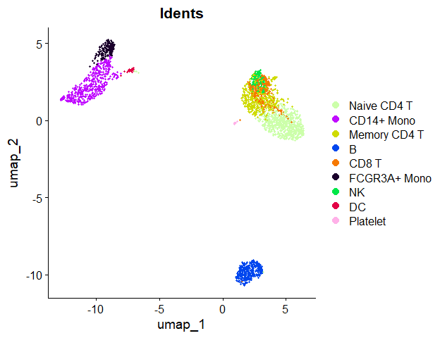

```r
   DimPlot2(pbmc, cols = c("#ccffaa","#c00bff","#cfdb00","#0147ee","#f67900","#1b002c","#00e748","#e30146","#ffb1e8"))
```

3. **Good Distinction and Coordination but Too Lively:** While certain vibrant schemes might be engaging in an advertising context, they may be considered too informal for professional journal standards. However, we recognize that sometimes higher contrast and more vibrant colors are needed for certain analyses or presentations. For these situations, we provide the “bright” color scheme (new in v1.2.0) while still recommending more subdued options for formal publications.

   Example of colors that might be too lively for formal publication but useful in other contexts:

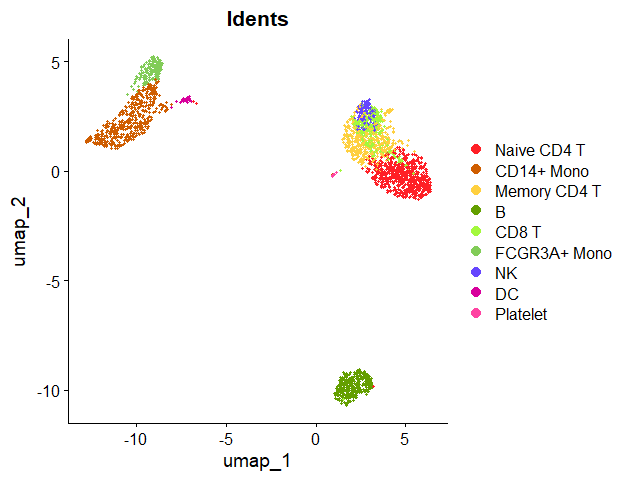

```r
   DimPlot2(pbmc, cols = c("#ff2026","#cf5d00","#ffd03f","#649f00","#a3f83d","#82cc58","#6645fe","#d8009c","#ff43a2"))
```

While the RColorBrewer package offers some good solutions, its options are limited and support a maximum of only 12 colors. This can be inadequate for visualizing data with a larger number of clusters. The default ggplot color palette, derived from hue_pal(), can assign an arbitrary number of colors, but similarly suffers from insufficient distinction when many colors are used. This is because the default palette differentiates colors only based on hue, without utilizing luminance and saturation, which limits its effectiveness. To address these limitations, `SeuratExtend` provides `color_pro`, which includes eight color schemes: “default”, “light”, “red”, “yellow”, “green”, “blue”, “purple”, and “bright” (new in v1.2.0). These presets are generated using the algorithm from I Want Hue (http://medialab.github.io/iwanthue/) with adjusted parameters, which is optimized for creating color palettes that are visually pleasing and distinctly separable.

#### Default Color Scheme

The “default” color scheme spans the entire hue domain but features reduced brightness and saturation, supporting 2 to 50 colors with five different presets per color. This scheme is ideal for general use where distinctiveness and subtlety are equally important.

> **Note**: In SeuratExtend v1.0.0, the “default” color scheme was the actual default setting (hence the name), representing a darker theme suitable for general visualizations. Based on user feedback, starting from v1.2.0, the “light” color scheme became the true default setting as users preferred it for better visibility, especially with labeled plots. However, we maintained the original naming convention—so “default” still refers to the darker theme. If you prefer the darker theme, you can manually specify `cols = "default"` in your function calls.

Example using the “default” color scheme:

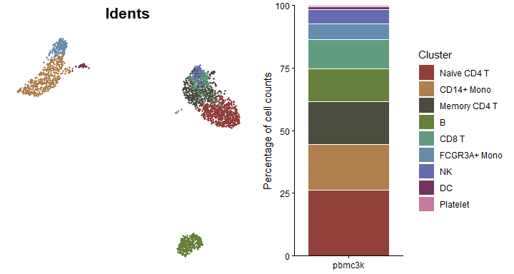

```r
library(cowplot)
library(SeuratExtend)
plot_grid(
  DimPlot2(pbmc, theme = NoAxes() + NoLegend(), cols = "default"),
  ClusterDistrBar(pbmc$orig.ident, pbmc$cluster, flip = FALSE, cols = "default") +
    theme(axis.title.x = element_blank())
)
```

#### Light Color Scheme

The “light” color scheme also covers the entire hue range but with increased brightness and reduced saturation, making it suitable when using labels with darker texts which may require a lighter background for visibility.

Example using the “light” color scheme:

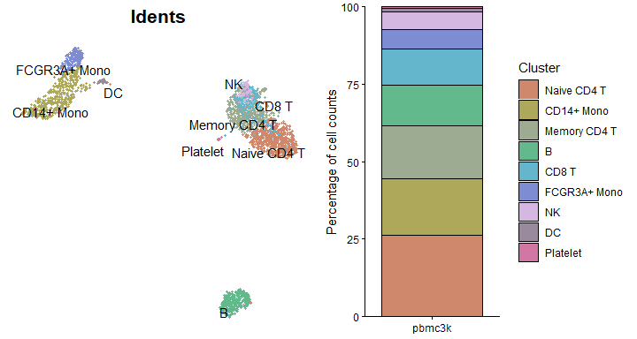

```r
plot_grid(
  DimPlot2(pbmc, label = TRUE, repel = TRUE, theme = NoAxes() + NoLegend()),
  ClusterDistrBar(pbmc$orig.ident, pbmc$cluster, cols = "light", flip = FALSE, border = "black") +
    theme(axis.title.x = element_blank())
)
```

#### Specialized Color Schemes

For color coordination that reflects the biological or categorical properties of the data, such as differentiating subtypes within a cell lineage, the specialized color schemes like “red”, “yellow”, “green”, “blue”, and “purple” offer hues confined to specific regions. These schemes support 2 to 25 colors, providing options that are both vibrant and harmonious without being overwhelming.

##### Red Color Scheme

Example using the “red” color scheme:

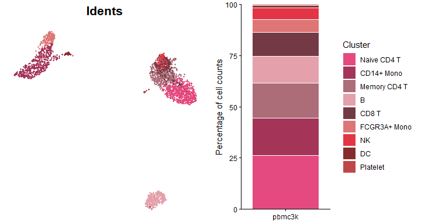

```r
plot_grid(
  DimPlot2(pbmc, cols = "pro_red", theme = NoAxes() + NoLegend()),
  ClusterDistrBar(pbmc$orig.ident, pbmc$cluster, cols = "pro_red", flip = FALSE) +
    theme(axis.title.x = element_blank())
)
```

##### Yellow Color Scheme

Example using the “yellow” color scheme:

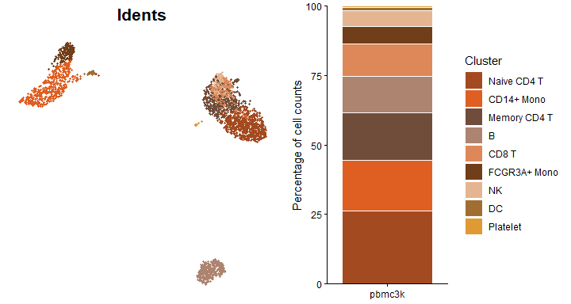

```r
plot_grid(
  DimPlot2(pbmc, cols = "pro_yellow", theme = NoAxes() + NoLegend()),
  ClusterDistrBar(pbmc$orig.ident, pbmc$cluster, cols = "pro_yellow", flip = FALSE) +
    theme(axis.title.x = element_blank())
)
```

##### Green Color Scheme

Example using the “green” color scheme:

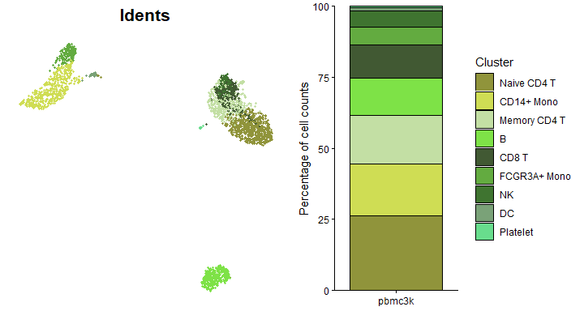

```r
plot_grid(
  DimPlot2(pbmc, cols = "pro_green", theme = NoAxes() + NoLegend()),
  ClusterDistrBar(pbmc$orig.ident, pbmc$cluster, cols = "pro_green", flip = FALSE, border = "black") +
    theme(axis.title.x = element_blank())
)
```

##### Blue Color Scheme

Example using the “blue” color scheme:

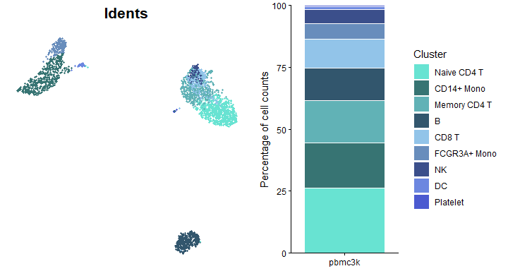

```r
plot_grid(
  DimPlot2(pbmc, cols = "pro_blue", theme = NoAxes() + NoLegend()),
  ClusterDistrBar(pbmc$orig.ident, pbmc$cluster, cols = "pro_blue", flip = FALSE) +
    theme(axis.title.x = element_blank())
)
```

##### Purple Color Scheme

Example using the “purple” color scheme:

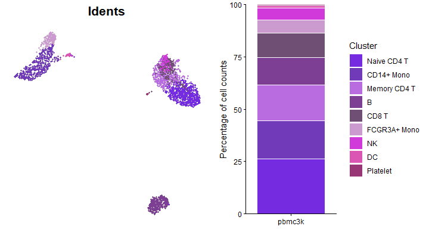

```r
plot_grid(
  DimPlot2(pbmc, cols = "pro_purple", theme = NoAxes() + NoLegend()),
  ClusterDistrBar(pbmc$orig.ident, pbmc$cluster, cols = "pro_purple", flip = FALSE) +
    theme(axis.title.x = element_blank())
)
```

#### Generating Color Codes

The `color_pro` function can generate between 2 to 50 colors:

```r
color_pro(n = 2)   # Example output: "#a05d49" "#6181a7"
color_pro(5)       # Example output: "#996742" "#5e824b" "#5d7880" "#7169a7" "#9f516c"
color_pro(10)      # Generates 10 colors
color_pro(20)      # Generates 20 colors
color_pro(50)      # Generates 50 colors
```

Visual demonstration of different color sets:

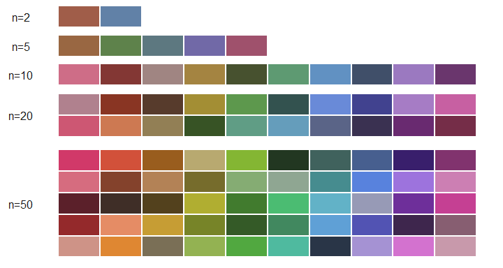

#### Available Color Schemes

`color_pro` offers eight different styles: “default”, “light”, “red”, “yellow”, “green”, “blue”, “purple”, and “bright”. Example generating 10 colors from each style:

```r
color_pro(10, col.space = 1)  # default
color_pro(10, 2)              # light
color_pro(10, 3)              # red
color_pro(10, 4)              # yellow
color_pro(10, 5)              # green
color_pro(10, 6)              # blue
color_pro(10, 7)              # purple
color_pro(10, 8)              # bright
```

Visual comparison:

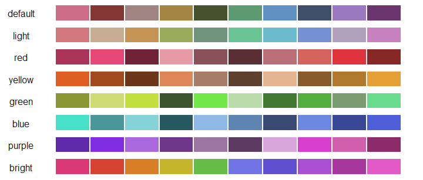

#### Sorting Options

`color_pro` supports sorting by “hue” (default) or by “difference” for enhanced distinction among colors. This feature can be specified by name or by numbers 1 or 2.

Example of sorting colors by hue and by difference:

```r
color_pro(10, 1, sort = "hue")
color_pro(10, 1, sort = "diff")
```

Visualizing the effect of different sorting methods:

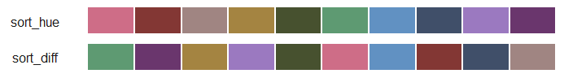

#### Random Sequence Options

Each color scheme and number of colors have five different random sequences available, providing variations even within the same parameters.

Example of generating different sets from the default color scheme:

```r
color_pro(10, 1, 1, set = 1)
color_pro(10, 1, 1, 2)
color_pro(10, 1, 1, 3)
color_pro(10, 1, 1, 4)
color_pro(10, 1, 1, 5)
```

Visualizing different random sequences:

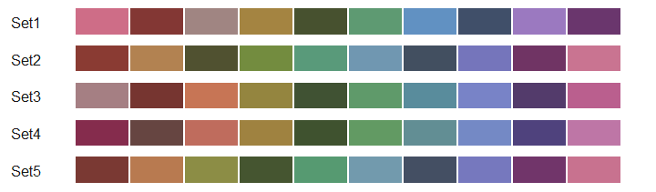

### IWantHue Color Series (`color_iwh`)

In addition to `color_pro`, `SeuratExtend` incorporates the `I Want Hue` algorithm to generate a series of color palettes. These palettes, known as `color_iwh`, include five default styles optimized for various visualization needs. Unlike `color_pro`, `color_iwh` does not support different sorting options and defaults to sorting by difference for maximum color distinction.

#### `color_iwh` Color Series Overview

The `color_iwh` function provides the following predefined color schemes:

- **default**: Suitable for general use with subtle color variations, supporting 2 to 20 colors.
- **intense**: Features vivid colors, supporting 2 to 30 colors, ideal for making impactful visual statements.
- **pastel**: Offers soft, soothing colors, supporting 2 to 18 colors, perfect for light-themed visualizations.
- **all**: Utilizes the full color spectrum with a soft k-means clustering approach, supporting 2 to 50 colors.
- **all_hard**: Also covers the full color spectrum but uses a hard force vector clustering method, supporting 30 to 50 colors.

#### Generating Colors with `color_iwh`

To generate colors using the `color_iwh` function, simply specify the number of colors and the style index. Here are examples of generating 10 colors from each predefined style:

Example of generating colors from each `color_iwh` style:

```r
color_iwh(10, 1)  # default
color_iwh(10, 2)  # intense
color_iwh(10, 3)  # pastel
color_iwh(10, 4)  # all
color_iwh(30, 5)  # all_hard
```

Visual comparison of `color_iwh` palettes:

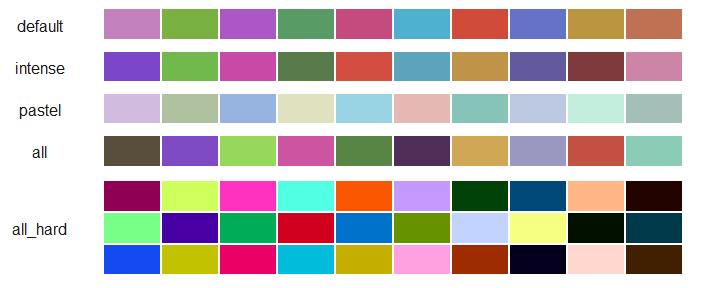

### Viridis and RColorBrewer Palettes

#### Viridis Options

The viridis package provides colorblind-friendly, perceptually uniform color scales. Here are all available options:

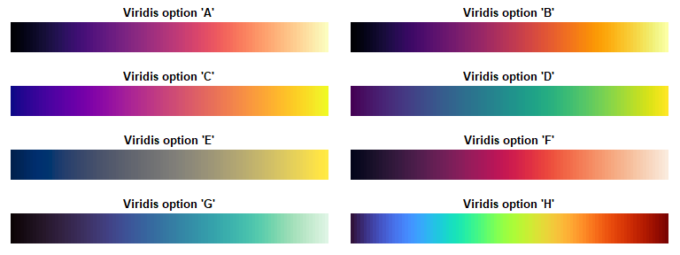

```r
library(viridis)
par(mfrow=c(4,2), mar=c(1,1,2,1))
for(option in LETTERS[1:8]) {
  image(1:100, 1, as.matrix(1:100), col=viridis(100, option=option),
        main=paste0("Viridis option '", toupper(option), "'"),
        xlab="", ylab="", axes=FALSE)
}
```

#### RColorBrewer Palettes

RColorBrewer provides carefully chosen color palettes for different types of data:

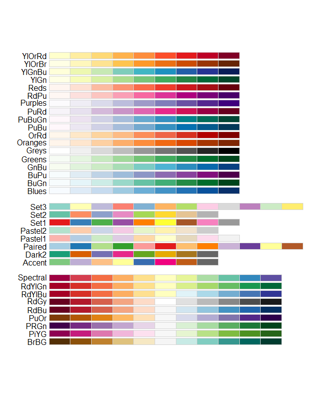

```r
library(RColorBrewer)
display.brewer.all()
```

### Additional Color Functions

#### Using `ryb2rgb()` to Convert RYB to RGB

The `ryb2rgb()` function translates RYB color values to RGB hex codes:

```r
ryb2rgb(c(r = 0.3, y = 0.5, b = 0.2))
```

```
## [1] "#CCAF80"
```

Visualizing primary and secondary colors:

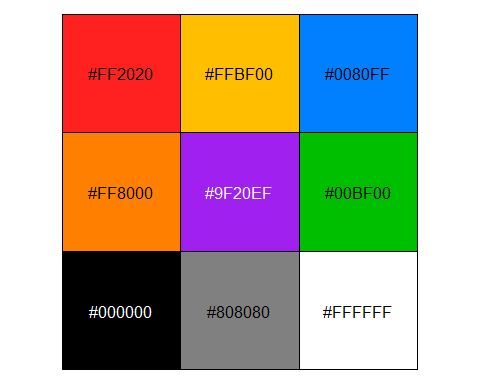

```r
library(scales)
library(dplyr)

data.frame(
  red = c(1, 0, 0),
  yellow = c(0, 1, 0),
  blue = c(0, 0, 1),
  orange = c(1, 1, 0),
  purple = c(1, 0, 1),
  green = c(0, 1, 1),
  black = c(1, 1, 1),
  grey = c(0.5, 0.5, 0.5),
  white = c(0, 0, 0)
) %>%
  apply(2, ryb2rgb) %>%
  show_col()
```

#### Using `save_colors` to Manage Color Settings

The `save_colors` function stores color settings within your Seurat object:

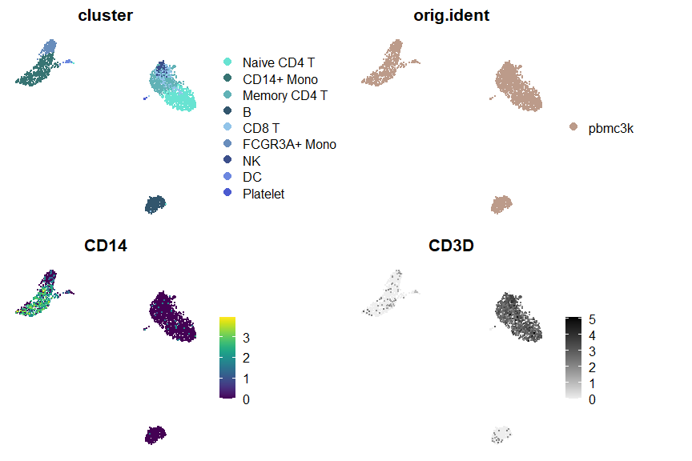

```r
# Save color settings
pbmc <- save_colors(pbmc, col_list = list(
  "cluster" = "pro_blue",
  "CD14" = "D",
  "CD3D" = c("#EEEEEE", "black")
))

# Now, when using DimPlot2, the specified colors for 'cluster', 'CD14', and 'CD3D' are automatically applied
DimPlot2(pbmc, features = c("cluster", "orig.ident", "CD14", "CD3D"), theme = NoAxes())
```

### Additional Resources

For more information about color palettes:

- RColorBrewer palettes: https://r-graph-gallery.com/38-rcolorbrewers-palettes.html
- Viridis palettes: https://cran.r-project.org/web/packages/viridis/vignettes/intro-to-viridis.html